# MA615 Assignment3

William Zen, Jack Carbaugh, Zara Waheed, Kosuke Sasaki

11/17/2021

# History and details

- Hurricane Katrina was a tropical cyclone that struck the southeastern United States in late August 2005.
- The hurricane and its aftermath claimed more than 1,800 lives
- Ranked as the costliest natural disaster in U.S. history
- Originated as a tropical depression from the merger of a tropical wave and the remnants of Tropical Depression Ten.

# Rainfall from hurricane data

The graph below shows the changes in rainfall levels as Katrina approached. As you can see, when you look at the days before and after the rainfall, there was only a bit of rainfall around Louisiana the day before the landfall, and the rain began to fall much more heavily along the Katrina track on the day of the landfall, and reached its maximum on that day. The next day, however, the rain disappeared again.

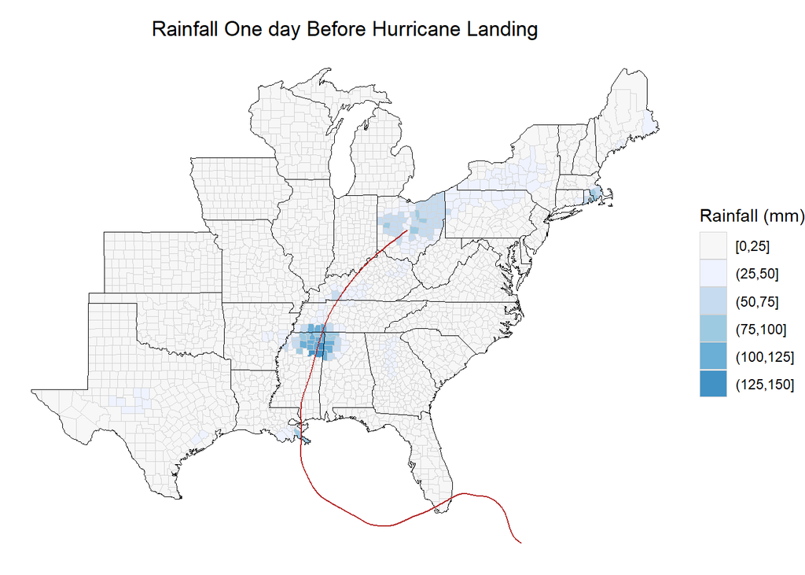

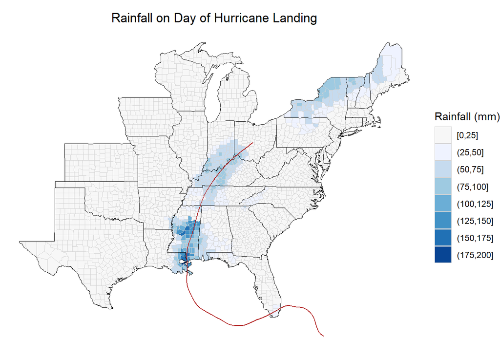

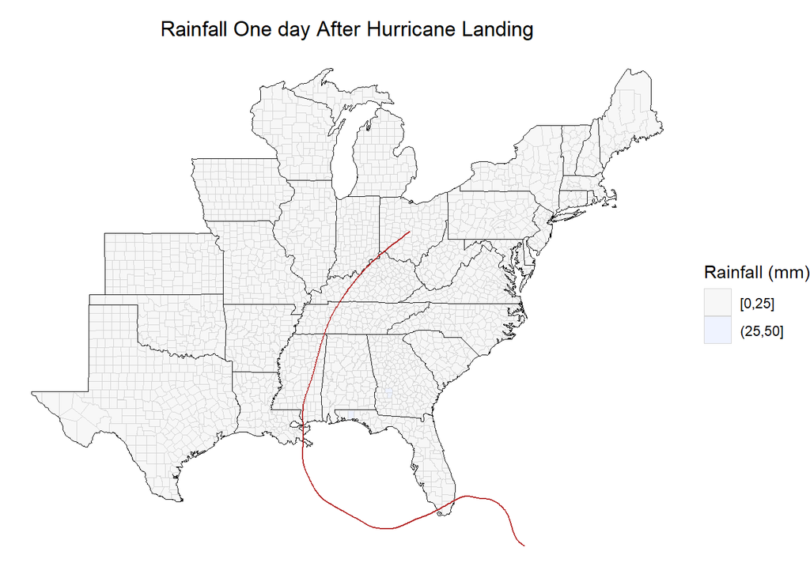

# Wind Hurricane Exposure map

From the Max Gust Map below, we see that the strongest winds are near the South of Louisiana, and we also see some strong gusts in the areas next to Louisiana. From the Max Sustained Winds, we see that the highgest winds appear along the Louisiana coast.

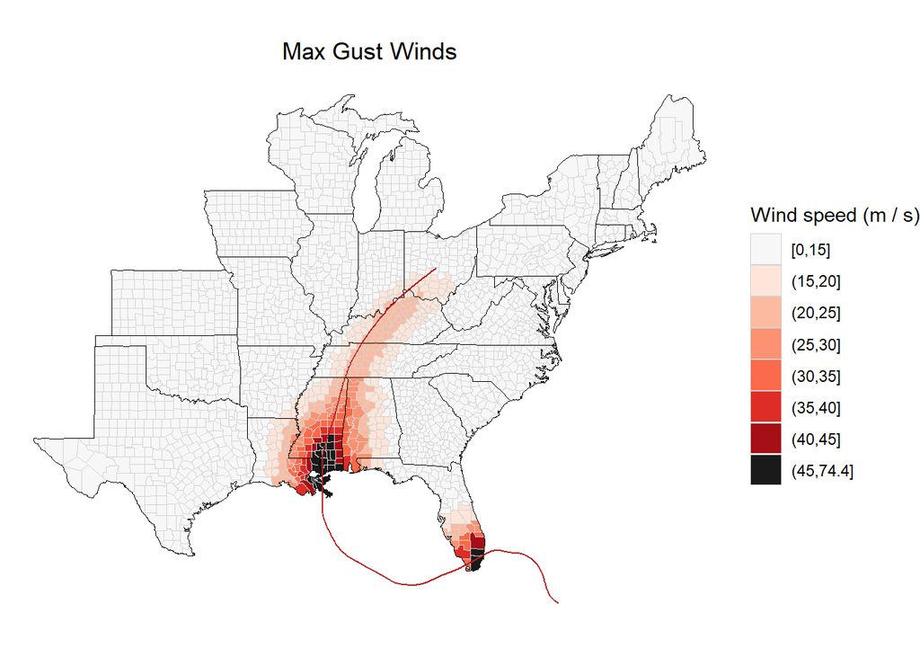

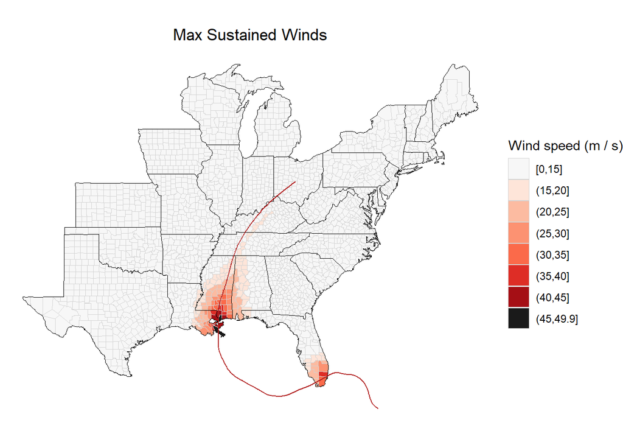

# Peak Gust Map (Ocean)

Looking at the Peak Gust Map, we see that the strongest winds are near the South of Louisiana. This matches up with the Hurricane Exposure map, as the Peak Gusts were also the strongest throughout this area. Both maps also show some strong gusts in the areas next to Louisiana, and much weaker to nonexistant gusts in the surrounding areas.

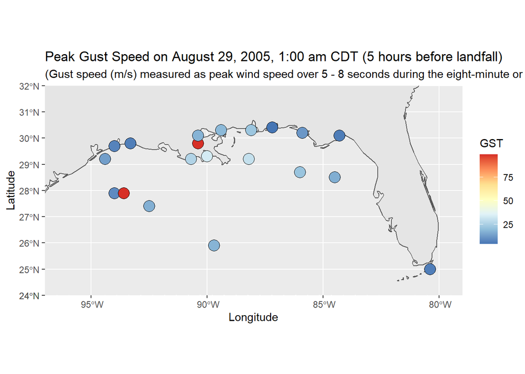

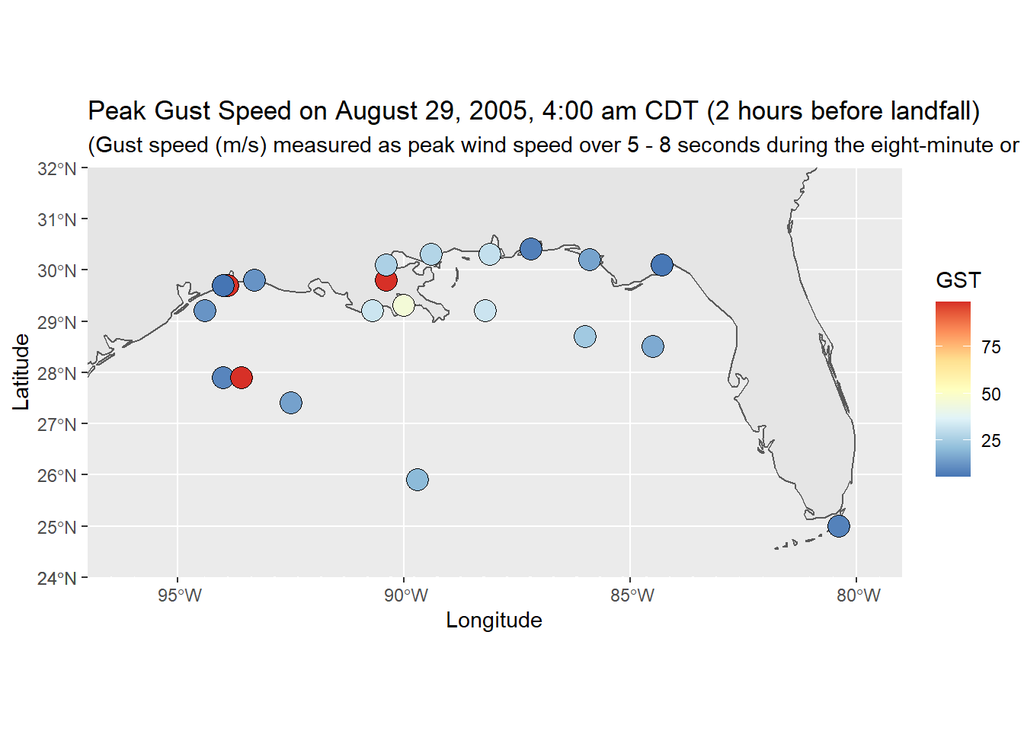

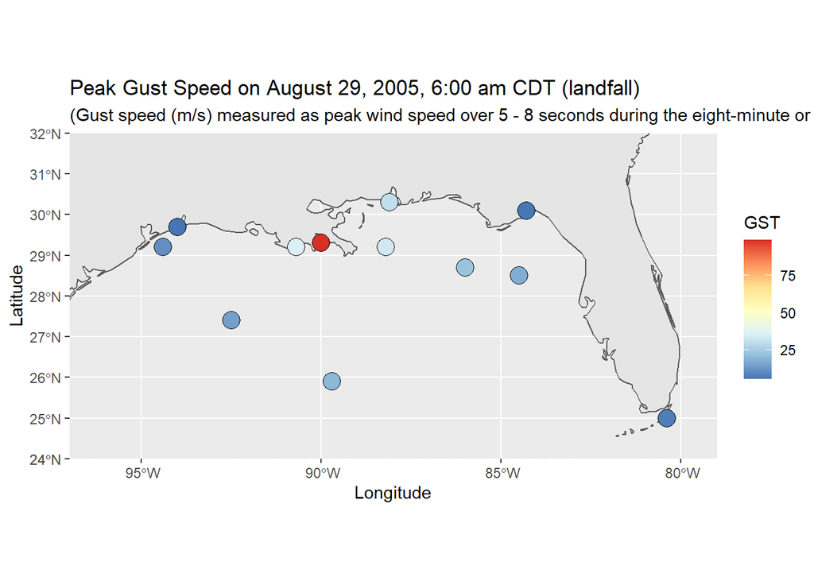

# Peak Gust Map (Land)

This map is comparable to the ocean map at the time of landfall. The maps are similar in Louisiana and Mississippi but not in Florida.

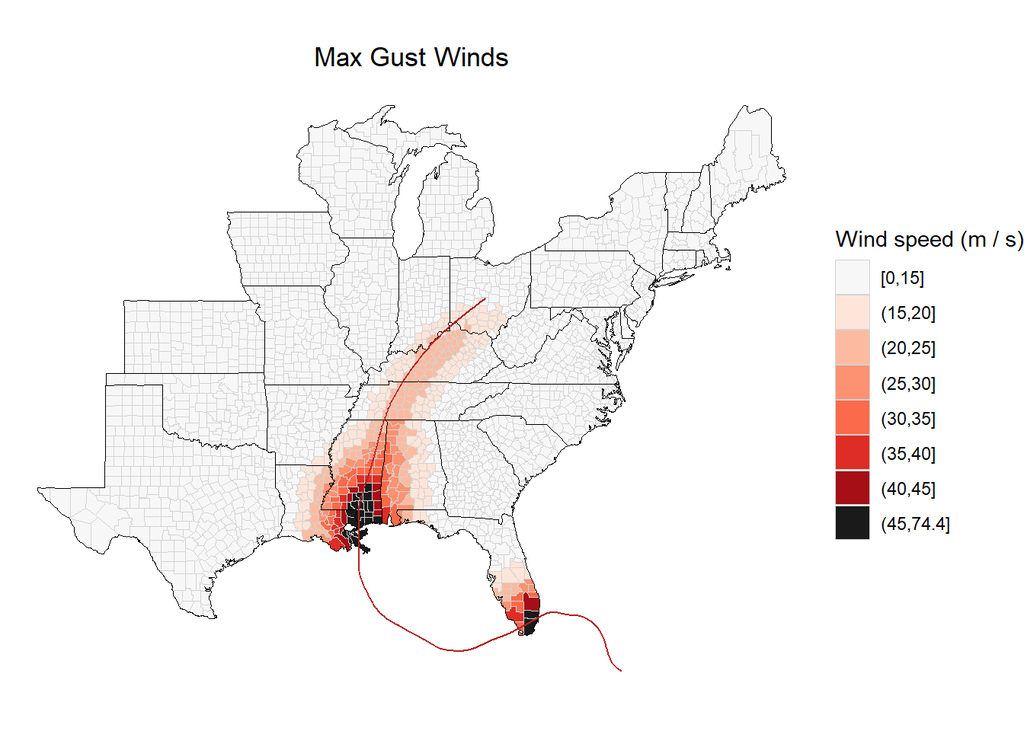

```r
map_counties("Katrina-2005", metric = "wind", wind_var = "vmax_gust") +
  ggtitle("Max Gust Winds") +
  theme(plot.title = element_text(hjust = 0.5))
```

# Wind Speed map (Ocean)

The Observations for the Peak Gust Map apply to the Wind Speed Map as well. The highgest winds from the buoy data appear along the Louisiana coast, matching up with what we see in the Hurricane Exposure map. The surrounding areas don’t show much higher winds than noraml, aligning with the Hurricane Exposure data.

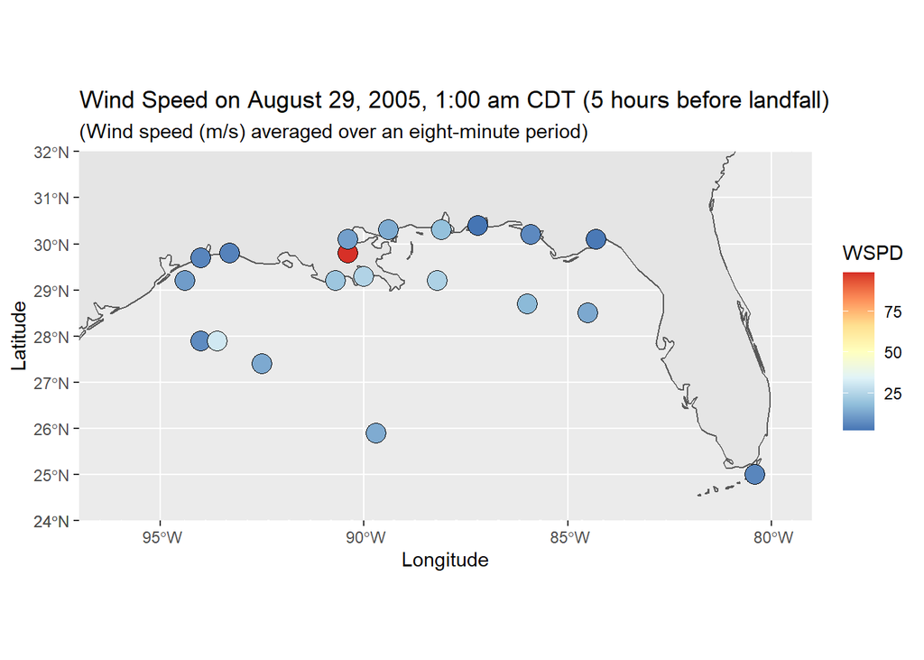

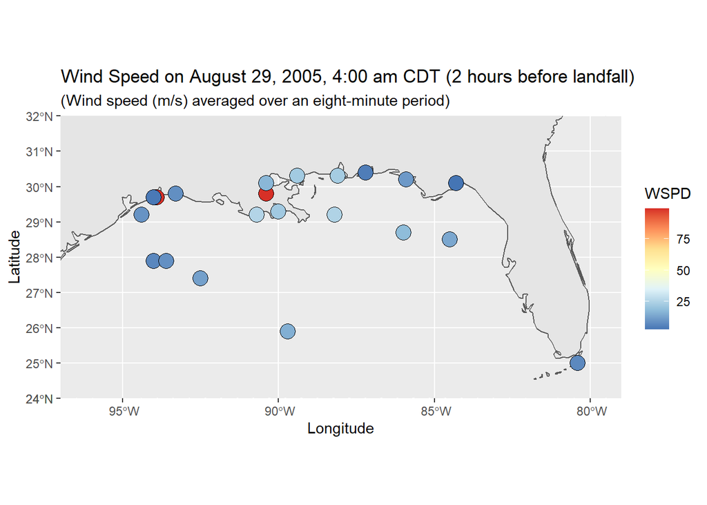

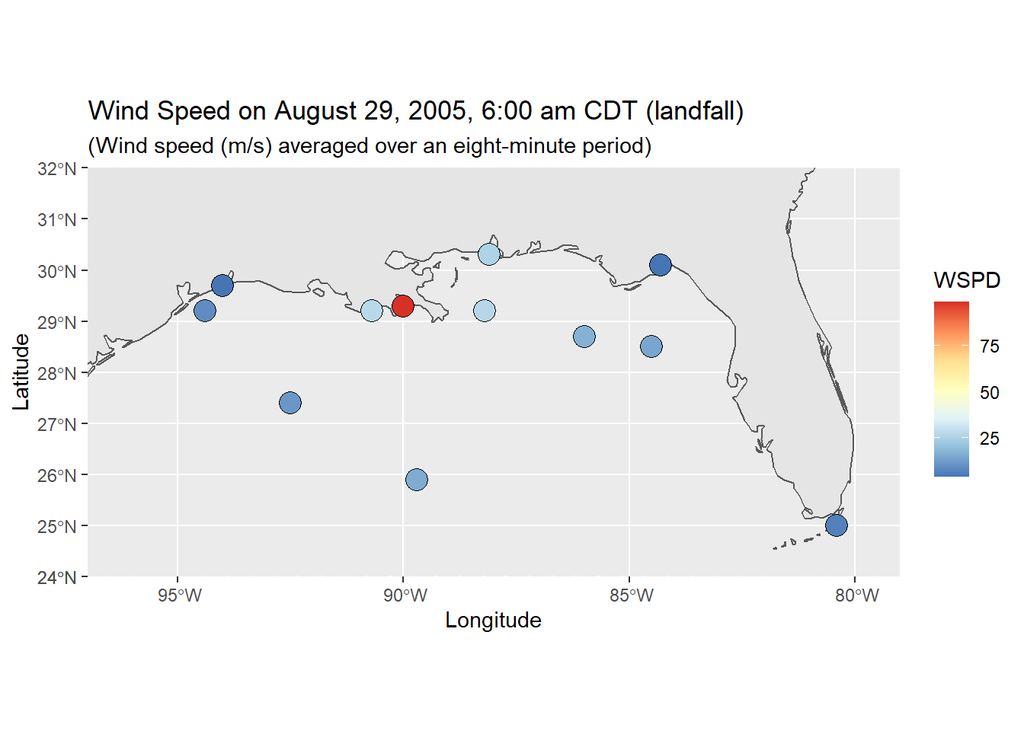

# Wind Speed map (Land)

The wind land map shows maximum sustained winds instead of average winds. But the maps are still very similar.

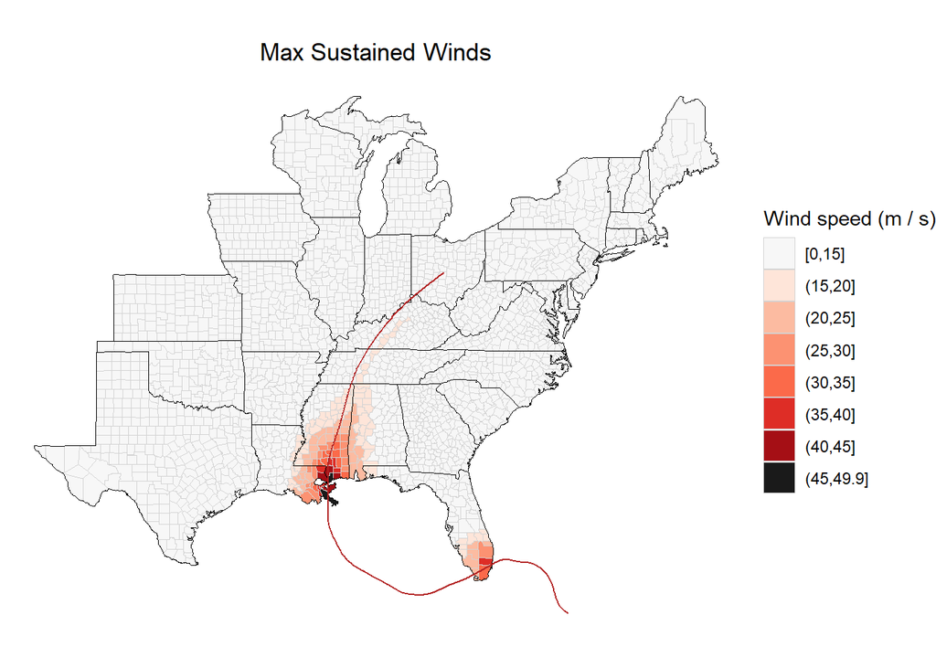

```r
map_counties("Katrina-2005", metric = "wind") +
  ggtitle("Max Sustained Winds") +
  theme(plot.title = element_text(hjust = 0.5))
```

# Variogram results

We displayed the variance between the gust speeds from different buoys at the time of landing in a variogram.

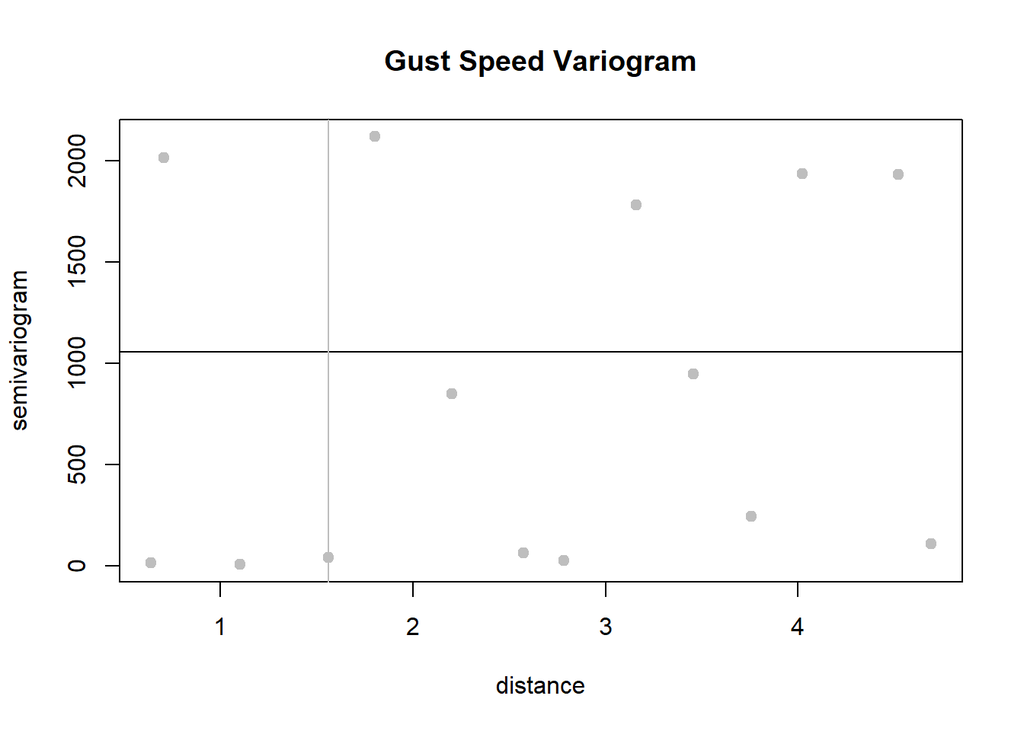

However, the variogram did not converge and the results were not very meaningful. Some reasons for this could be:

- We used too small a number of buoys to get the sense of a significant relationship between them.
- The buoy data is measured inconsistently
- Missing data values are shown as extremely high values instead of no data values.